```python
import pandas as pd
import numpy as np
!pip install dalex
import dalex as dx  # <- colab
import matplotlib.pyplot as plt

from sklearn.ensemble import RandomForestRegressor
```

# Task

- take a dataset you want
- perform an exploratory data analysis (data visualization)
- create a pipeline for data preprocessing
- add new features (one hot encoding for example)
- add predictive model as the last step of the pipeline
- prepare a report with model explainability

## Importing the dataset and dependencies

We're going to explore the California Housing dataset from https://scikit-learn.org/stable/datasets/real_world.html#california-housing-dataset.

```python
# imports
import pandas as pd
import numpy as np
!pip install dalex  # <- colab
import dalex as dx
import matplotlib.pyplot as plt
!pip install scikit-learn-extra  # <- colab
from sklearn_extra.cluster import KMedoids
import seaborn as sns
```

```python
# data
from sklearn.datasets import fetch_california_housing

data = fetch_california_housing()
df = pd.DataFrame(data['data'], columns=data['feature_names'])
df['target'] = data['target']

# check for missing data
missing_data = df.isna()
if missing_data.any().any():
  print('Missing data:')
  display(missing_data)
else:
  print('No missing data')

df
```

```
No missing data
```

|  | MedInc | HouseAge | AveRooms | AveBedrms | Population | AveOccup | Latitude | Longitude | target |
| --- | --- | --- | --- | --- | --- | --- | --- | --- | --- |
| 0 | 8.3252 | 41.0 | 6.984127 | 1.023810 | 322.0 | 2.555556 | 37.88 | -122.23 | 4.526 |
| 1 | 8.3014 | 21.0 | 6.238137 | 0.971880 | 2401.0 | 2.109842 | 37.86 | -122.22 | 3.585 |
| 2 | 7.2574 | 52.0 | 8.288136 | 1.073446 | 496.0 | 2.802260 | 37.85 | -122.24 | 3.521 |
| 3 | 5.6431 | 52.0 | 5.817352 | 1.073059 | 558.0 | 2.547945 | 37.85 | -122.25 | 3.413 |
| 4 | 3.8462 | 52.0 | 6.281853 | 1.081081 | 565.0 | 2.181467 | 37.85 | -122.25 | 3.422 |
| ... | ... | ... | ... | ... | ... | ... | ... | ... | ... |
| 20635 | 1.5603 | 25.0 | 5.045455 | 1.133333 | 845.0 | 2.560606 | 39.48 | -121.09 | 0.781 |
| 20636 | 2.5568 | 18.0 | 6.114035 | 1.315789 | 356.0 | 3.122807 | 39.49 | -121.21 | 0.771 |
| 20637 | 1.7000 | 17.0 | 5.205543 | 1.120092 | 1007.0 | 2.325635 | 39.43 | -121.22 | 0.923 |
| 20638 | 1.8672 | 18.0 | 5.329513 | 1.171920 | 741.0 | 2.123209 | 39.43 | -121.32 | 0.847 |
| 20639 | 2.3886 | 16.0 | 5.254717 | 1.162264 | 1387.0 | 2.616981 | 39.37 | -121.24 | 0.894 |

20640 rows × 9 columns

## Data visualization

### Basic statistics

```python
stats_df = pd.DataFrame({'Min': df.min(), 'Mean': df.mean(), 'Median': df.median(), 'Max': df.max()})
print(stats_df)
```

```
                   Min         Mean       Median           Max
MedInc        0.499900     3.870671     3.534800     15.000100
HouseAge      1.000000    28.639486    29.000000     52.000000
AveRooms      0.846154     5.429000     5.229129    141.909091
AveBedrms     0.333333     1.096675     1.048780     34.066667
Population    3.000000  1425.476744  1166.000000  35682.000000
AveOccup      0.692308     3.070655     2.818116   1243.333333
Latitude     32.540000    35.631861    34.260000     41.950000
Longitude  -124.350000  -119.569704  -118.490000   -114.310000
target        0.149990     2.068558     1.797000      5.000010
```

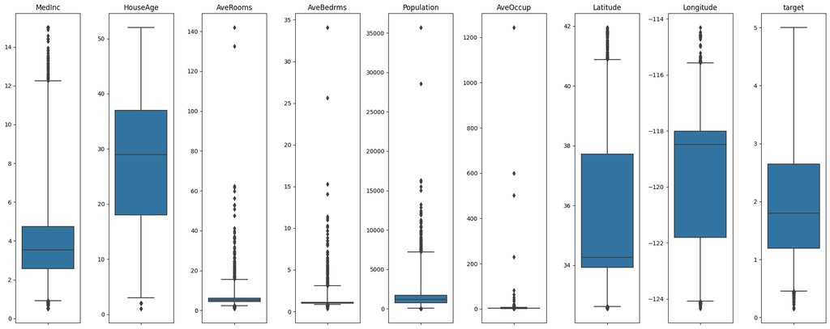

```
Boxplots cover 99% of the data
```

```python
fig, ax = plt.subplots(1, len(df.columns), figsize=(20, 8))

for i, column in enumerate(df.columns):
  sns.boxplot(data=df[column], ax=ax[i], whis=(0.5, 99.5))
  ax[i].set_title(f'{column}')
  ax[i].set_xticklabels('')

plt.tight_layout()
plt.show()
print("Boxplots cover 99% of the data")
```

### Frequency histograms

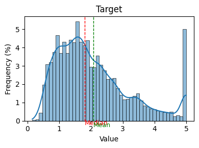

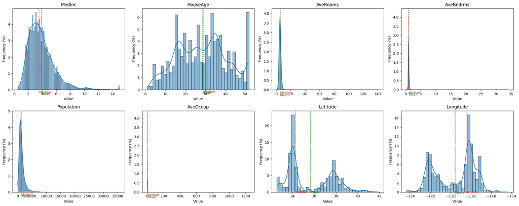

```python
# frequency histograms of target
fig, ax = plt.subplots(figsize=(4, 3))

sns.histplot(df['target'], kde=True, stat='percent')
median = df['target'].median()
ax.axvline(median, color='r', linestyle='dashed', linewidth=1)
ax.annotate('Median', xy=(median, 0.2), xytext=(median, -16/72), color='r', fontsize=9)
mean = df['target'].mean()
ax.axvline(mean, color='g', linestyle='dashed', linewidth=1)
ax.annotate('Mean', xy=(mean, 0.2), xytext=(mean, -24/72), color='g', fontsize=9)
ax.set_title('Target')
ax.set_xlabel('Value')
ax.set_ylabel('Frequency (%)')

plt.tight_layout()
plt.show()

# frequency histograms of each feature
fig, ax = plt.subplots(nrows=2, ncols=4, figsize=(20, 8))
ax = ax.flatten()

for i, feature in enumerate(df.columns.drop('target')):
  sns.histplot(df[feature], ax=ax[i], kde=True, stat='percent')
  median = df[feature].median()
  ax[i].axvline(median, color='r', linestyle='dashed', linewidth=1)
  ax[i].annotate('Median', xy=(median, 0.2), xytext=(median, -16/72), color='r', fontsize=9)
  mean = df[feature].mean()
  ax[i].axvline(mean, color='g', linestyle='dashed', linewidth=1)
  ax[i].annotate('Mean', xy=(mean, 0.2), xytext=(mean, -24/72), color='g', fontsize=9)
  ax[i].set_title(feature)
  ax[i].set_xlabel('Value')
  ax[i].set_ylabel('Frequency (%)')

plt.tight_layout()
plt.show()
```

### Analyzing the highly skewed distibutions

As we can see from the boxplots and frequency histograms, a few features are highly skewed, namely: AveRooms, AveBedrms, Population, AveOccup. Although we may feel tempted to call these outliers, we need to **take into account the domain knowledge**.

#### AveRooms, AveBedrms

As for AveRooms and AveBedrooms, we can read the following on the [documentation page](https://scikit-learn.org/stable/datasets/real_world.html#california-housing-dataset) about the data:

> A household is a group of people residing within a home. Since the average number of rooms and bedrooms in this dataset are provided per household, these columns may take surprisingly large values for block groups with few households and many empty houses, such as vacation resorts.

Based on this, we cannot treat those as outliers - being a block group with many empty houses is a valid feature we should take into account when creating the regression model.

### Correlation

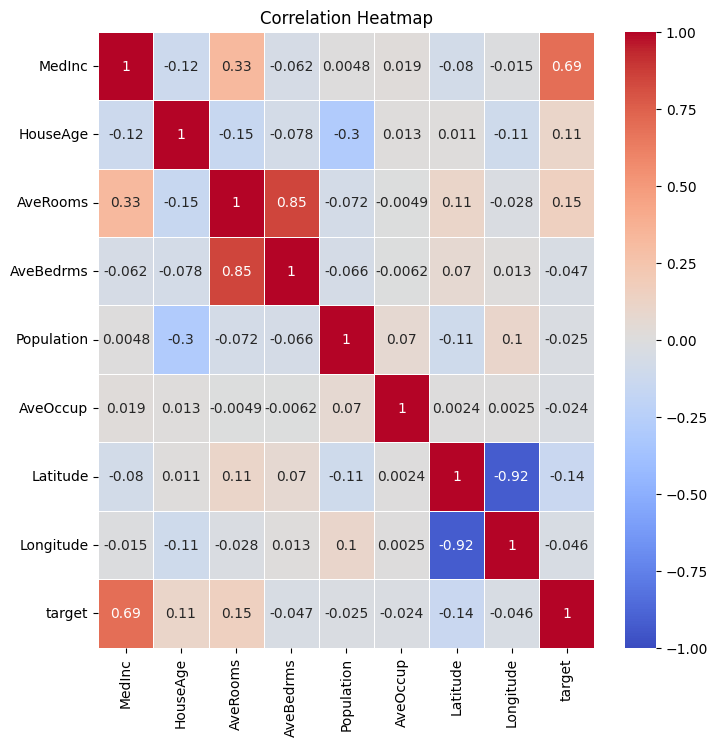

```python
plt.figure(figsize=(8, 8))
sns.heatmap(df.corr(), annot=True, cmap="coolwarm", linewidths=.5, vmin=-1, vmax=1)
plt.title("Correlation Heatmap")
plt.show()
```

### Latitude and Longitude correlation

As we can see from the heatmap, Latitude and Longitude are highly correlated, with the coefficient of `-0.92`. This makes sense given the geographical shape and location of California:

[figure not shown]

For the most part, California goes diagonal to the Latitude and Longitude - as Latitude increases, Longitude decreases, and vice-versa.

However, combining those into single feature (which would be intuitively similar to fitting a diagonal line across California and mapping house locations onto that line) is not necessarily a good idea. For example, a house by the seaside may be mapped into the same place as house on the opposite end - that would mean there's no difference in price depending on proximiti to the coast, which we know is not true.

Instead, a set of new features may be created, based on the raw geographical location data. We'll try the following:

- distance to Los Angeles
- distance to Sacramento
- distance to San Francisco

The following could also be beneficial, but since the purpose of this task is model explainability, and those are more complex (for cities, we can simply get their Latitude and Longitude - the following data is lines, which require more hustle), dropping the idea for the time being. May revisit those in the future.

- distance to the sea shore
- distance to the borders of the neighboring states

## Adding new features

```python
# we'll be using Haversine distance, which takes into account proper handling
# of the curvature of the Earth
!pip install haversine
from haversine import haversine

# Latitude, Longitude
los_angeles = (34.0549, -118.2426)
sacramento = (38.5816, -121.4944)
san_francisco = (37.7749, -122.4294)

df['distance_los_angeles'] = df.apply(lambda row: haversine((row['Latitude'], row['Longitude']), los_angeles), axis=1)
df['distance_sacramento'] = df.apply(lambda row: haversine((row['Latitude'], row['Longitude']), sacramento), axis=1)
df['distance_san_francisco'] = df.apply(lambda row: haversine((row['Latitude'], row['Longitude']), san_francisco), axis=1)

display(df)
```

|  | MedInc | HouseAge | AveRooms | AveBedrms | Population | AveOccup | Latitude | Longitude | target | distance_los_angeles | distance_sacramento | distance_san_francisco |
| --- | --- | --- | --- | --- | --- | --- | --- | --- | --- | --- | --- | --- |
| 0 | 8.3252 | 41.0 | 6.984127 | 1.023810 | 322.0 | 2.555556 | 37.88 | -122.23 | 4.526 | 556.362354 | 101.066379 | 21.054285 |
| 1 | 8.3014 | 21.0 | 6.238137 | 0.971880 | 2401.0 | 2.109842 | 37.86 | -122.22 | 3.585 | 554.113429 | 102.254449 | 20.685139 |
| 2 | 7.2574 | 52.0 | 8.288136 | 1.073446 | 496.0 | 2.802260 | 37.85 | -122.24 | 3.521 | 554.445277 | 104.215009 | 18.616185 |
| 3 | 5.6431 | 52.0 | 5.817352 | 1.073059 | 558.0 | 2.547945 | 37.85 | -122.25 | 3.413 | 555.029140 | 104.763267 | 17.835415 |
| 4 | 3.8462 | 52.0 | 6.281853 | 1.081081 | 565.0 | 2.181467 | 37.85 | -122.25 | 3.422 | 555.029140 | 104.763267 | 17.835415 |
| ... | ... | ... | ... | ... | ... | ... | ... | ... | ... | ... | ... | ... |
| 20635 | 1.5603 | 25.0 | 5.045455 | 1.133333 | 845.0 | 2.560606 | 39.48 | -121.09 | 0.781 | 654.293547 | 105.828333 | 222.445670 |
| 20636 | 2.5568 | 18.0 | 6.114035 | 1.315789 | 356.0 | 3.122807 | 39.49 | -121.21 | 0.771 | 659.513232 | 103.953308 | 218.144179 |
| 20637 | 1.7000 | 17.0 | 5.205543 | 1.120092 | 1007.0 | 2.325635 | 39.43 | -121.22 | 0.923 | 653.809496 | 97.271717 | 211.926539 |
| 20638 | 1.8672 | 18.0 | 5.329513 | 1.171920 | 741.0 | 2.123209 | 39.43 | -121.32 | 0.847 | 657.467779 | 95.533859 | 207.755292 |
| 20639 | 2.3886 | 16.0 | 5.254717 | 1.162264 | 1387.0 | 2.616981 | 39.37 | -121.24 | 0.894 | 648.492018 | 90.382319 | 205.301119 |

20640 rows × 12 columns

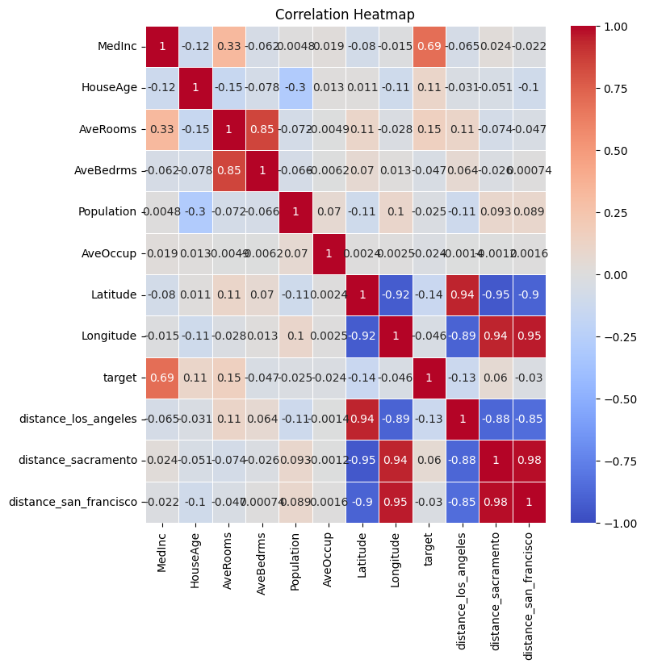

```python
# correlation after adding new features
plt.figure(figsize=(8, 8))
sns.heatmap(df.corr(), annot=True, cmap="coolwarm", linewidths=.5, vmin=-1, vmax=1)
plt.title("Correlation Heatmap")
plt.show()
```

## Model

```python
import pandas as pd
from sklearn.model_selection import train_test_split
from sklearn.ensemble import RandomForestRegressor
from sklearn.metrics import mean_squared_error

X = df.drop('target', axis=1)
y = df.target
X_train, X_test, y_train, y_test = train_test_split(X, y, test_size=0.2, random_state=420)

rf_model = RandomForestRegressor(n_estimators=100, random_state=42)
rf_model.fit(X_train, y_train)

y_pred = rf_model.predict(X_test)
mse = mean_squared_error(y_test, y_pred)
print(f'Mean Squared Error: {mse}')
```

```
Mean Squared Error: 0.24376913421990998
```

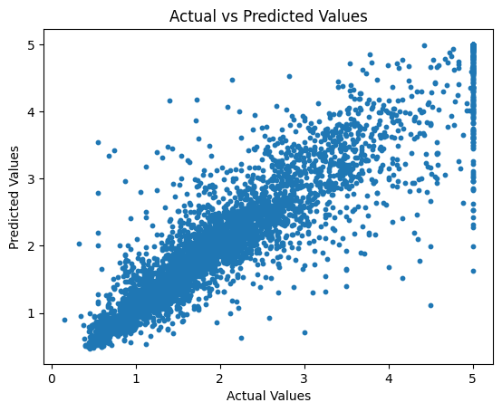

```python
import matplotlib.pyplot as plt

plt.scatter(y_test, y_pred, s=10)
plt.xlabel("Actual Values")
plt.ylabel("Predicted Values")
plt.title("Actual vs Predicted Values")
plt.show()
```

## Explainability report

```python
exp = dx.Explainer(rf_model, X, y)
```

```
Preparation of a new explainer is initiated

  -> data              : 20640 rows 11 cols
  -> target variable   : Parameter 'y' was a pandas.Series. Converted to a numpy.ndarray.
  -> target variable   : 20640 values
  -> model_class       : sklearn.ensemble._forest.RandomForestRegressor (default)
  -> label             : Not specified, model's class short name will be used. (default)
  -> predict function  : <function yhat_default at 0x78ed28002290> will be used (default)
  -> predict function  : Accepts pandas.DataFrame and numpy.ndarray.
```

```
  -> predicted values  : min = 0.341, mean = 2.07, max = 5.0
  -> model type        : regression will be used (default)
  -> residual function : difference between y and yhat (default)
  -> residuals         : min = -3.0, mean = -0.00273, max = 3.38
  -> model_info        : package sklearn

A new explainer has been created!
```

```python
fi = exp.model_parts()
fi.plot()
```

[interactive chart not shown]

As we can see from the Variable Importance plot:

- The most impactful factor in determining the house price is the Median income in the block group. That seems quite logical - according to supply and demand, how much people earn drives how expensive houses they may afford
- The second most important non-location factor is Average number of household members (3rd place of all factors, just short of the 2nd one - Latitude). Speculation is that it may affect the price so much because the single-person family owners, or owners of an empty house may be willing to sell them for cheaper than houses in which a 4-member family may live. We will check this hypothesis in the next part of the analysis - the model profile.
- Latitude and Longitude rank high on the importance scale (place 2 and 5 respectively, with Latitude being about 33% more important). It means that:
  - Location plays an important part in determining the price of the house.
  - Although quite important (especially distance to Los Angeles, which is a bit more important than Longitude), distances to the 3 major cities is not sufficient to capture all what's important regarding the location.
- Distances to the 3 major cities rank quite high on the importance scale:
  - Distance to Los Angeles scores the highest of the 3 cities, and is higher than the Longitude itself. It is, among many things, the home to Hollywood, one of the top tourist destinations in the world, and a centre of diverse economy. It's safe to assume the closer to LA, the higher the price.
  - Distance to San Francisco scores the second of the 3 cities (about 14% less important than LA). San Francisco is an internationally recognized city and a major economic hub (especially for technology sector). On top of that, the geography limits the space for new construction (hills, bodies of water) - limited supply and growing demand tend to increase property prices.
  - Distance to Sacramento scores the lowest of the 3 cities (about 35% less important than LA). It lies close to San Francisco, so these distances are highly correlated. It is the capital of California and a developed city, so its proximity affects the price of houses.
- The median house age in the block scores place 8 out of 10 in terms of importance (only about 20% as important as Median income). It may affect the price because of:
  - The willingness (or reluctane) of certain age groups to buy/sell the houses - affecting the supply and demand.
  - The hidden feature within the median age - if it's low, it may mean that there's relatively many families with small children, that may be reluctant to selling their houses - affecting the supply and demand
- Surprisingly, average number of rooms places 9 out of 10 in terms of importance (only about half as important as the median house age). That may be due to the same reason a bottle of water is much more expensive on a plane than in a grocery shop - the value of a commodity (many rooms) depends on the surrounding context (location, income, etc.). A 5-room house in the middle of nowhere can easily go for less than a single-room apartment in the middle of LA.
- Population scores the last (10/10) in terms of importance (just 7% of the 1st). It may be because it's already captured by all the location-related factors.
- Note that the average number of bedrooms doesn't affect the model's prediction. That may be because of the same reasons the average number of rooms places relatively low, combined with the fact that a "formal assignment" of a room as a bedroom may not be as impactful - a room can easily become a bedroom, the same way a bedroom can be used for other purposes.

We will explore the hypotheses based on the model profile.

```python
exp.model_profile().plot()
```

[interactive chart not shown]

As we can see from the model profile:

- Median income in the block group - besides the dip in the in the very low-end of the feature, there's a clear uptrend. The higher median income, the more expensive the houses. This seems intuitive - how much people earn drives how expensive houses they may afford, and people who earn more tend to choose houses of higher standard (in terms of location, equipment, etc.), which are put up for a higher price.
- House Age - there's a small, but stable increase in the price, the higher the house age. That may be because as people get older, they may be more reluctant to sell their homes, so it takes more money to buy them.
- Average number of rooms - there's a small (though relatively higher than in the case of house age), but stable increase in the price as the no. of rooms increases.
  - Although average number of bedrooms has no impact on the model, it's worth noting that the plot of how it influences the price is strikingly similar to Average number of rooms, which may confirm the hypothesis from variable importance.
- Population - besides the initial dip, there's a very slight increase of price, as population increases up to 10k people. After reaching 10k, it seems to have no influence on the price. The initial dip may be the fact that in less populated areas (such as countryside), the trend may be such that less populated areas are valued higher than more densely ones.
- Average Occupation - the influence of average occupation is strikingly odd - the price decreases sharply from 0 to about 13 household members, and then the price doesn't change as it increases to the max. That's because of the fact mentioned by the data collectors: *"Since the average number of rooms and bedrooms in this dataset are provided per household, these columns may take surprisingly large values for block groups with few households and many empty houses, such as vacation resorts."* - this maps into this pattern - so we may interpret these results as:
  - For "regular" cases, the larger the number of occupants, the lower the price.
  - For cases mentioned by the data collectors, such as vacation resorts, the no. of occupants doesn't affect the price.
- Latitude and Longitude - let's analyze these together:
  - In case of Latitude, there's a quite substantial decrease in price as Latitude increases (i.e. as we move North) - till about 38 degrees North. After this point, the decrease is negligible.
  - In case of Longitude, there's a quite substantial decrease in price, as Longitude increases (i.e. as we move East) - it's negligible till about 122 degrees West, then relatively high till about 117 degrees, and then negligible again.
  - Since these are highly correlated, and the fact about California's geography, we may determine the following:
    - In the Northern part of California (from 38 degrees North, about in between San Francisco and Sacramento), the Latitude doesn't play as much part as Longitude - it seems that the closer to the coast, the better.
    - Below that Northern part, as we move more South, we also move more East (and vice versa), and the price decreases - that would suggest that in this part, the closer to the shore and to the Northern part, the higher the price.
- Distance to Los Angeles - in close proximity to Los Angeles (till about 200km away), the price decreases sharply, as we move away from Los Angeles. After about 200km, it has relatively no effect on the price.
- Distance to San Francisco - the price decreases sharply till about 100km away from the city, then it's decreases slowly, but surely, with a relatively sharp decrease at 550-600km away.
- Distance to Sacramento - surprisingly, the price increases quite significantly as we move away from Sacramento, up to about 160km away (which may be due to fact it correlates with getting closer to San Francisco), then seems to have no effect till a similar relatively sharp decrease at 550-600km away.

Note that the **relatively sharp decrease and a small bump up** in price at about 550-600km from Sacramento and San Francisco **may likely be due to the close area to Los Angeles**. The cities happen to be at about that distance.

We may find the groups of similar blocks and have a look at their characteristics:

[output not shown]

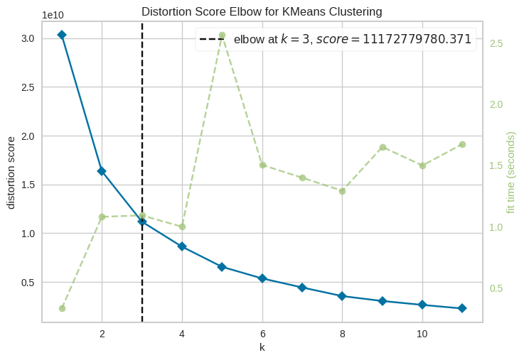

```python
!pip install yellowbrick

from sklearn import datasets
from sklearn.cluster import KMeans
from yellowbrick.cluster import KElbowVisualizer

km = KMeans(random_state=420)
visualizer = KElbowVisualizer(km, n_init=10, k=(1,12))

visualizer.fit(X)
visualizer.show()
```

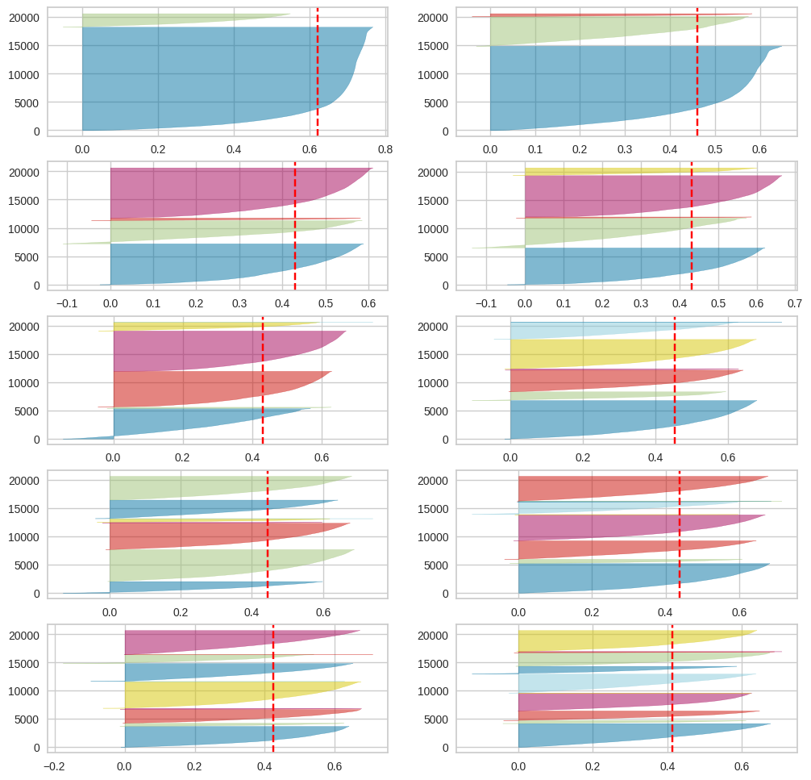

```python
from sklearn import datasets
from sklearn.cluster import KMeans
import matplotlib.pyplot as plt
from yellowbrick.cluster import SilhouetteVisualizer

fig, ax = plt.subplots(5, 2, figsize=(12,12))
for i in range(2, 12):
  km = KMeans(n_clusters=i, init='k-means++', n_init=10, random_state=420)
  q, mod = divmod(i, 2)
  visualizer = SilhouetteVisualizer(km, colors='yellowbrick', ax=ax[q-1][mod])
  visualizer.fit(X)
```

The elbow point method for finding the optimal K gives the maximum score to K=3. However, the elbow point is not clear.

To target this, we can analyze it using the Silhouette method:

- for K=3, we can see that there are big differences in size between the clusters
- for K=4, we can see that except the one cluster that emerged clear already in K=2, the clusters are of siimilar enough size, they all score quite well in terms of the score (which is above than the average score on the dataset - red line)
- for K=5, we can see that the average score doesn't change much from K=4, but the clusters scores either stay more or less unchanged, or improve quite much, while not increasing their overlap significantly
- starting from K=6, the score of individual clusters drop, and the overlap is quite big

For these points, **K=5** will be chosen.

Now that we have the K, we can find the best representatives from each cluster (similar block groups):

```python
kmeans = KMeans(n_clusters=5, init='k-means++', n_init=10, random_state=420)
clusters = kmeans.fit_predict(X)

df_with_clusters = df.copy()
df_with_clusters['cluster'] = clusters

display(df_with_clusters)
```

|  | MedInc | HouseAge | AveRooms | AveBedrms | Population | AveOccup | Latitude | Longitude | target | distance_los_angeles | distance_sacramento | distance_san_francisco | cluster |
| --- | --- | --- | --- | --- | --- | --- | --- | --- | --- | --- | --- | --- | --- |
| 0 | 8.3252 | 41.0 | 6.984127 | 1.023810 | 322.0 | 2.555556 | 37.88 | -122.23 | 4.526 | 556.362354 | 101.066379 | 21.054285 | 0 |
| 1 | 8.3014 | 21.0 | 6.238137 | 0.971880 | 2401.0 | 2.109842 | 37.86 | -122.22 | 3.585 | 554.113429 | 102.254449 | 20.685139 | 1 |
| 2 | 7.2574 | 52.0 | 8.288136 | 1.073446 | 496.0 | 2.802260 | 37.85 | -122.24 | 3.521 | 554.445277 | 104.215009 | 18.616185 | 0 |
| 3 | 5.6431 | 52.0 | 5.817352 | 1.073059 | 558.0 | 2.547945 | 37.85 | -122.25 | 3.413 | 555.029140 | 104.763267 | 17.835415 | 0 |
| 4 | 3.8462 | 52.0 | 6.281853 | 1.081081 | 565.0 | 2.181467 | 37.85 | -122.25 | 3.422 | 555.029140 | 104.763267 | 17.835415 | 0 |
| ... | ... | ... | ... | ... | ... | ... | ... | ... | ... | ... | ... | ... | ... |
| 20635 | 1.5603 | 25.0 | 5.045455 | 1.133333 | 845.0 | 2.560606 | 39.48 | -121.09 | 0.781 | 654.293547 | 105.828333 | 222.445670 | 0 |
| 20636 | 2.5568 | 18.0 | 6.114035 | 1.315789 | 356.0 | 3.122807 | 39.49 | -121.21 | 0.771 | 659.513232 | 103.953308 | 218.144179 | 0 |
| 20637 | 1.7000 | 17.0 | 5.205543 | 1.120092 | 1007.0 | 2.325635 | 39.43 | -121.22 | 0.923 | 653.809496 | 97.271717 | 211.926539 | 0 |
| 20638 | 1.8672 | 18.0 | 5.329513 | 1.171920 | 741.0 | 2.123209 | 39.43 | -121.32 | 0.847 | 657.467779 | 95.533859 | 207.755292 | 0 |
| 20639 | 2.3886 | 16.0 | 5.254717 | 1.162264 | 1387.0 | 2.616981 | 39.37 | -121.24 | 0.894 | 648.492018 | 90.382319 | 205.301119 | 0 |

20640 rows × 13 columns

```python
cluster_data = {i: df_with_clusters[df_with_clusters['cluster'] == i] for i in range(5)}
for i in cluster_data.keys():
  cluster_data[i] = cluster_data[i].reset_index()

class_examples = 3  # 3 examples from each class
representatives = {i: None for i in cluster_data.keys()}
for i in cluster_data.keys():
  print(f'cluster {i}')
  kmedoids = KMedoids(n_clusters=class_examples, random_state=420)
  kmedoids.fit(cluster_data[i])
  representatives[i] = cluster_data[i].iloc[kmedoids.medoid_indices_].reset_index(drop=True)
  display(representatives[i])
```

```
cluster 0
```

|  | index | MedInc | HouseAge | AveRooms | AveBedrms | Population | AveOccup | Latitude | Longitude | target | distance_los_angeles | distance_sacramento | distance_san_francisco | cluster |
| --- | --- | --- | --- | --- | --- | --- | --- | --- | --- | --- | --- | --- | --- | --- |
| 0 | 10076 | 3.0043 | 24.0 | 16.793296 | 3.427374 | 780.0 | 2.178771 | 39.32 | -120.26 | 1.22100 | 612.415806 | 134.667114 | 255.153016 | 0 |
| 1 | 1433 | 4.5900 | 37.0 | 5.014286 | 0.934286 | 882.0 | 2.520000 | 37.99 | -122.03 | 1.66600 | 554.388305 | 80.701039 | 42.435288 | 0 |
| 2 | 18064 | 7.8711 | 34.0 | 7.923288 | 1.131507 | 903.0 | 2.473973 | 37.25 | -122.03 | 5.00001 | 493.189559 | 155.342262 | 68.173382 | 0 |

```
cluster 1
```

|  | index | MedInc | HouseAge | AveRooms | AveBedrms | Population | AveOccup | Latitude | Longitude | target | distance_los_angeles | distance_sacramento | distance_san_francisco | cluster |
| --- | --- | --- | --- | --- | --- | --- | --- | --- | --- | --- | --- | --- | --- | --- |
| 0 | 11412 | 6.9261 | 24.0 | 7.150754 | 1.035176 | 1954.0 | 3.273032 | 33.69 | -117.95 | 2.846 | 48.744981 | 630.074916 | 607.938311 | 1 |
| 1 | 17694 | 5.0709 | 33.0 | 6.048421 | 1.029474 | 1946.0 | 4.096842 | 37.28 | -121.82 | 1.764 | 482.661340 | 147.521557 | 76.917108 | 1 |
| 2 | 4443 | 1.9881 | 37.0 | 3.600791 | 0.984190 | 1961.0 | 3.875494 | 34.09 | -118.21 | 1.592 | 4.924325 | 579.544214 | 558.623260 | 1 |

```
cluster 2
```

|  | index | MedInc | HouseAge | AveRooms | AveBedrms | Population | AveOccup | Latitude | Longitude | target | distance_los_angeles | distance_sacramento | distance_san_francisco | cluster |
| --- | --- | --- | --- | --- | --- | --- | --- | --- | --- | --- | --- | --- | --- | --- |
| 0 | 14558 | 6.3570 | 4.0 | 6.114372 | 1.070513 | 7301.0 | 2.463225 | 32.95 | -117.22 | 3.225 | 155.190097 | 735.211952 | 714.568201 | 2 |
| 1 | 9697 | 2.0244 | 19.0 | 3.915744 | 1.035206 | 11272.0 | 4.458861 | 36.69 | -121.61 | 1.185 | 423.112955 | 210.582723 | 140.765728 | 2 |
| 2 | 5924 | 7.4837 | 8.0 | 7.773191 | 1.054731 | 7249.0 | 3.362245 | 34.13 | -117.76 | 3.587 | 45.217699 | 597.240227 | 583.724295 | 2 |

```
cluster 3
```

|  | index | MedInc | HouseAge | AveRooms | AveBedrms | Population | AveOccup | Latitude | Longitude | target | distance_los_angeles | distance_sacramento | distance_san_francisco | cluster |
| --- | --- | --- | --- | --- | --- | --- | --- | --- | --- | --- | --- | --- | --- | --- |
| 0 | 14530 | 4.7266 | 16.0 | 6.053640 | 0.923372 | 917.0 | 3.513410 | 32.92 | -117.13 | 1.911 | 163.004269 | 742.357675 | 722.524655 | 3 |
| 1 | 8748 | 6.2247 | 36.0 | 6.088737 | 1.061433 | 901.0 | 3.075085 | 33.82 | -118.36 | 3.390 | 28.276115 | 599.423857 | 572.658690 | 3 |
| 2 | 4950 | 1.7386 | 50.0 | 4.993174 | 1.208191 | 912.0 | 3.112628 | 34.01 | -118.31 | 1.094 | 7.968799 | 582.866821 | 559.295178 | 3 |

```
cluster 4
```

|  | index | MedInc | HouseAge | AveRooms | AveBedrms | Population | AveOccup | Latitude | Longitude | target | distance_los_angeles | distance_sacramento | distance_san_francisco | cluster |
| --- | --- | --- | --- | --- | --- | --- | --- | --- | --- | --- | --- | --- | --- | --- |
| 0 | 17529 | 2.0972 | 36.0 | 3.012658 | 1.090190 | 3561.0 | 5.634494 | 37.33 | -121.88 | 1.875 | 490.346872 | 143.218761 | 69.231513 | 4 |
| 1 | 11549 | 6.0609 | 25.0 | 6.582792 | 1.025974 | 3613.0 | 2.932630 | 33.74 | -118.01 | 2.649 | 41.072473 | 622.513333 | 600.107853 | 4 |
| 2 | 4586 | 1.7238 | 33.0 | 1.926877 | 1.034585 | 3707.0 | 3.663043 | 34.06 | -118.26 | 1.100 | 1.700290 | 580.202065 | 558.086134 | 4 |

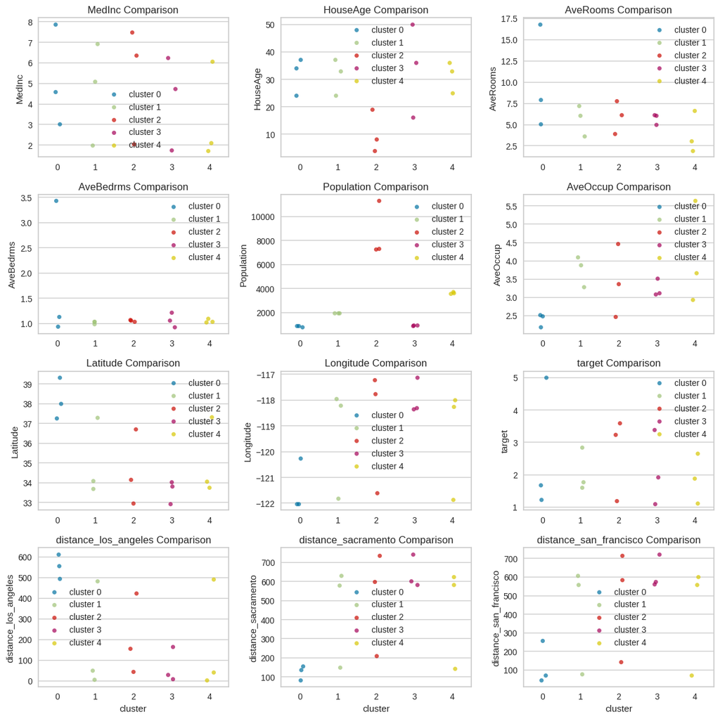

```python
import matplotlib.pyplot as plt
import seaborn as sns

# comparison plots of features between the examples
representative_class_dfs = pd.concat([representatives[i] for i in cluster_data.keys()])
features = df.columns

fig, axes = plt.subplots(nrows=4, ncols=3, figsize=(12, 12))

for row in range(4):
    for col in range(3):
        ax = axes[row, col]

        if row * 3 + col < len(features):
            # Create a scatterplot for each class
            for class_label in range(5):
                subset = representative_class_dfs[representative_class_dfs['cluster'] == class_label]
                sns.stripplot(x='cluster', y=features[row * 3 + col], data=subset, jitter=True, ax=ax, label=f'cluster {class_label}', alpha=0.7)

            ax.set_title(f'{features[row * 3 + col]} Comparison')
            ax.set_xlabel('cluster')
            ax.set_ylabel(features[row * 3 + col])
            ax.legend()
        else:
            # Remove y-axis label for empty subplots
            ax.set_ylabel('')

        # Remove x-axis label for all subplots except the last row
        if row < 3:
            ax.set_xlabel('')

plt.tight_layout()
plt.show()
```

Cluster 2:

- notable properties:
  - about 12yo house age
  - about 6 rooms on average and 1 bedroom
  - highly dense - population of about 9,000 people per block
  - about 3.5 occupation
  - 1 representative low end of price $125k, somewhat close to Sacramento (200km) and San Francisco (150km), probably the low end of income ($20k)
  - 2 representatives in the higher end of price $340k, quite close to (50km and 150km) Los Angeles, probably the higher end of income (about $70k)
- the 1 representative may be a relatively poor family with a single parent and 2-3 children to support

Cluster 3:

- notable properties:
  - about 6-7 rooms on average. relatively higher avg bedrooms compared to groups 1, 2, and 4
  - realtively sparsely populated - about 1,000 people per block
  - about 3 occupants on average
  - 2 representatives in LA (no farther than 40km)
  - 1 representative relatively close to LA (175km)
  - price varies - from really low (about $110k, to about $340k)

Cluster 4: